# Airbnb en Euskadi

montera34

April 12, 2017

# Airbnb en Euskadi

Airbnb en Euskadi, según los datos obtenidos por InsideAirbnb, contiene 2902 anuncios en 266 municipios, de ellos 395 tienen licencia de alojamiento turístico (13.6%).

En las capitales tenemos:

- **Donostia - San Sebastián** 1219 anuncios (42.0 % del total), de esos alojamientos tienen licencia 160 (13.1 % del municipio). Dispone de 4553 plazas. Anfitriones con alojamiento listado 696.
- **Bilbao** 457 (15.7% del total), de esos alojamientos tienen licencia 74 (16.2 % del municipio). Dispone de 1480 plazas. Anfitriones con alojamiento listado 365.
- **Vitoria - Gasteiz** 114 (3.9% del total), de esos alojamientos tienen licencia 0 (0.0 % del municipio). Dispone de 396 plazas. Anfitriones con alojamiento listado 86.

Por comparar con otras ciudades, el porcentaje de alojamientos con licencia turística en Barcelona es 18.0% de un total de 17369 alojamientos según datos de insideairbnb. Madrid (7446 alojamientos) y Mallorca (11271 alojamientos) no tienen indicado si tienen licencia.

# Efecto Airbnb en Donostia

En Donostia existen 696 anfitriones con alojamientos disponibles en Airbnb.

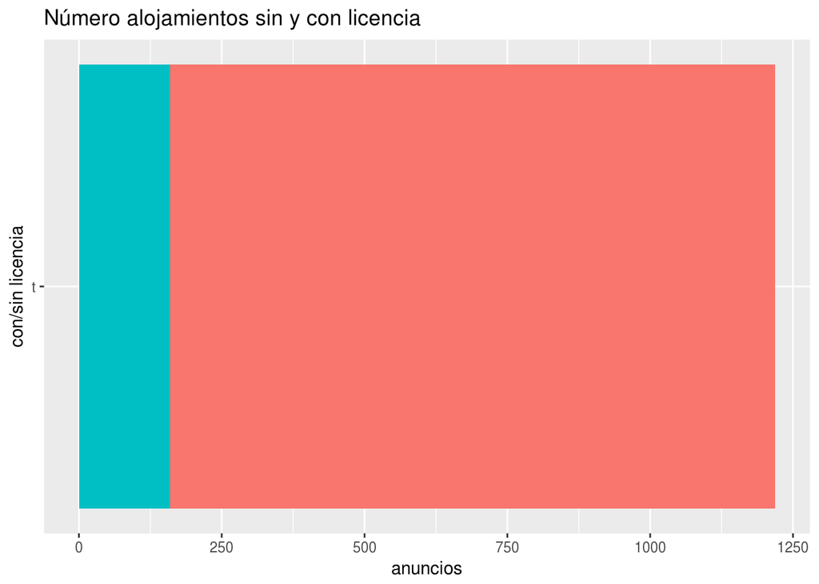

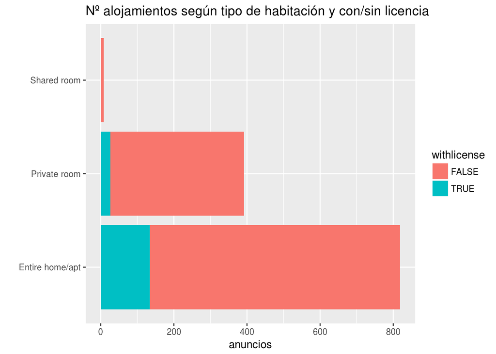

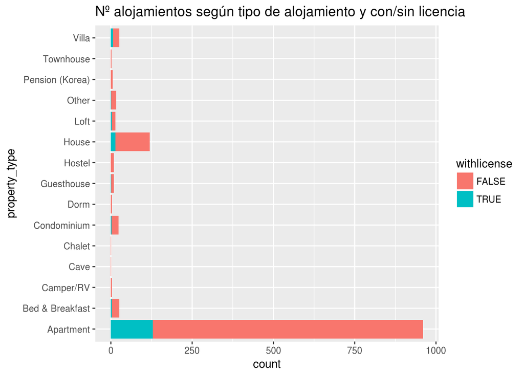

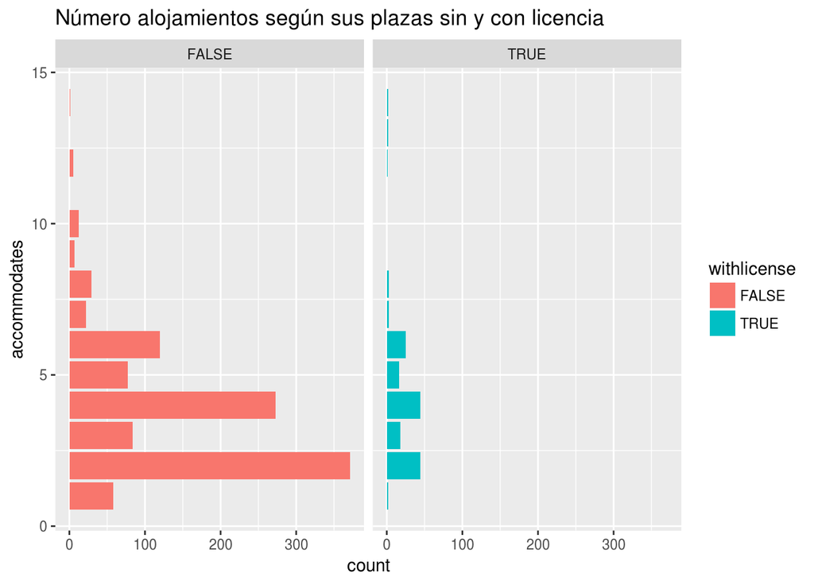

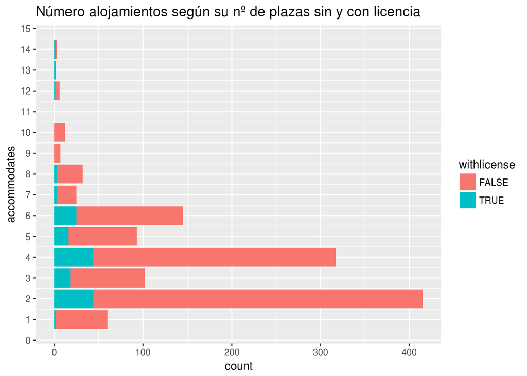

## Anfitriones en Airbnb

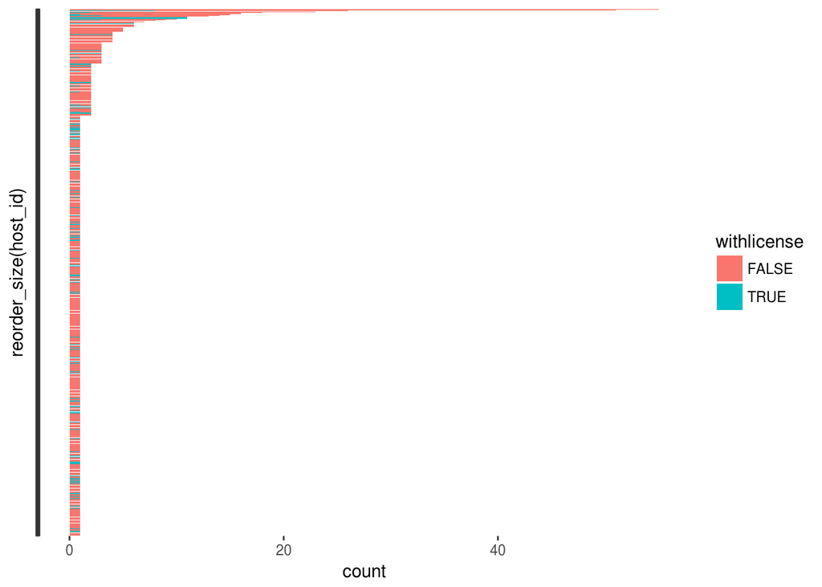

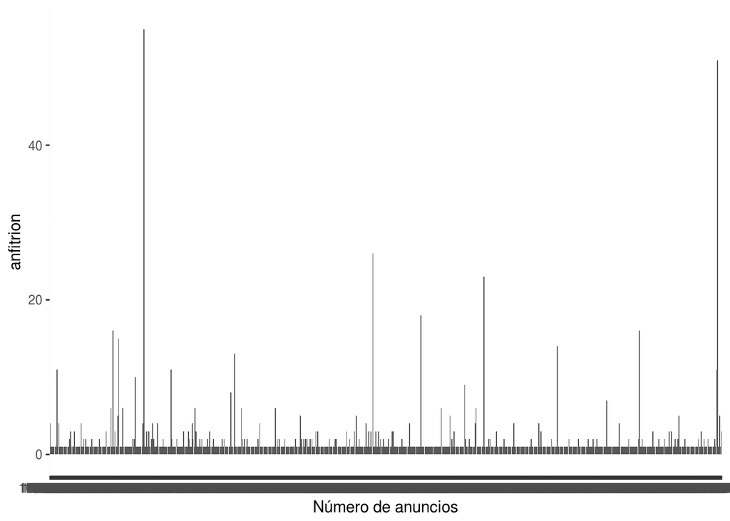

### Los anfitriones con más alojamientos

Los 20 anfitriones con más alojamientos (id)

| host_id | alojamientos |
| --- | --- |
| 15707672 | 55 |
| 98419892 | 51 |
| 3952766 | 26 |
| 5254782 | 23 |
| 4614604 | 18 |
| 790667 | 16 |
| 12954077 | 16 |
| 13367653 | 15 |
| 6598471 | 14 |
| 25039584 | 13 |
| 18192487 | 11 |
| 98189424 | 11 |
| 102583389 | 11 |
| 149691 | 10 |
| 50920106 | 9 |
| 2470030 | 8 |
| 73815563 | 7 |
| 2035832 | 6 |
| 2625306 | 6 |
| 5173315 | 6 |

### Los anfitriones con más plazas

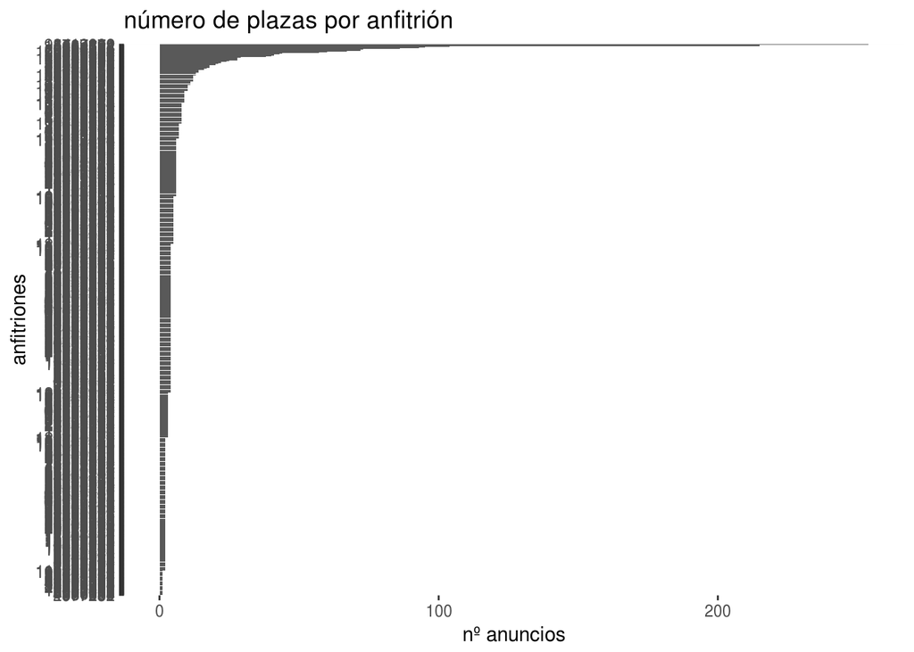

Los 10 primeros anfitriones (1.4% del total de anfitriones) con más plazas tienen 1119 plazas disponibles (que son el 24.6% del total de plazas).

Los 20 primeros anfitriones (2.9% del total de anfitriones) con más plazas tienen 1495 plazas disponibles (que son el 32.8% del total de plazas).

Los 50 primeros anfitriones (7.2% del total de anfitriones) con más plazas tienen 1958 plazas disponibles (que son el 43.0% del total de plazas).

Los 100 primeros anfitriones (14.4% del total de anfitriones) con más plazas tienen 2392 plazas disponibles (que son el 52.5% del total de plazas).

Los 30 anfitriones con más alojamientos (id) tienen n plazas (accomodates)

| host_id | plazas |
| --- | --- |
| 98419892 | 254 |
| 15707672 | 215 |
| 4614604 | 104 |
| 5254782 | 95 |
| 3952766 | 93 |
| 12954077 | 86 |
| 6598471 | 73 |
| 25039584 | 72 |
| 13367653 | 67 |
| 102583389 | 60 |
| 98189424 | 57 |
| 2470030 | 44 |
| 50920106 | 43 |
| 18192487 | 41 |
| 790667 | 40 |
| 13725999 | 38 |
| 149691 | 29 |
| 10650761 | 28 |
| 63853491 | 28 |
| 109977260 | 28 |
| 2035832 | 25 |
| 1589633 | 24 |
| 5172999 | 22 |
| 5173315 | 22 |
| 37985139 | 21 |
| 49473712 | 20 |
| 26474511 | 18 |
| 38990075 | 18 |
| 71316977 | 18 |
| 85246818 | 18 |

### Número de reviews por cada alojamiento

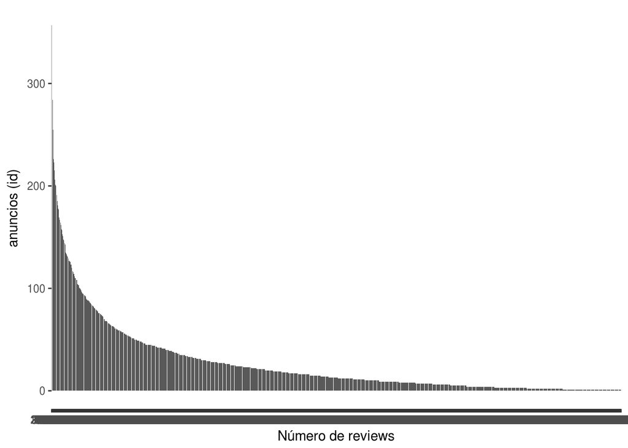

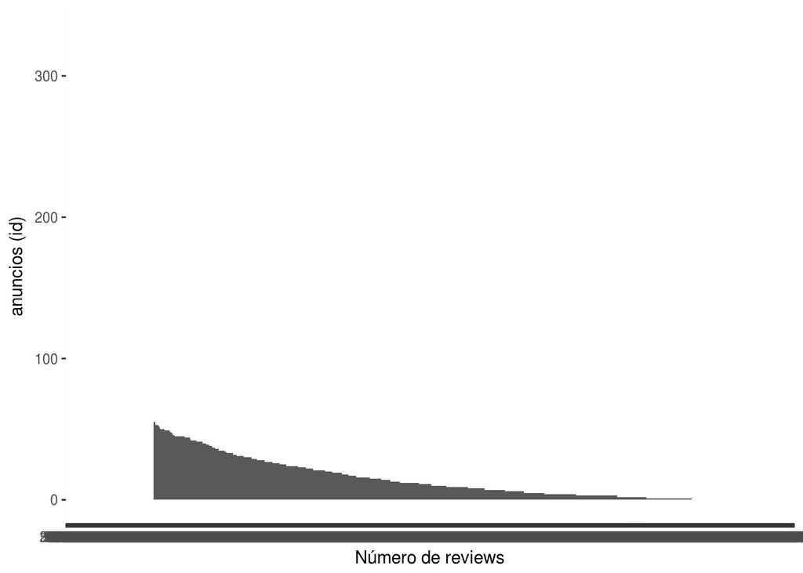

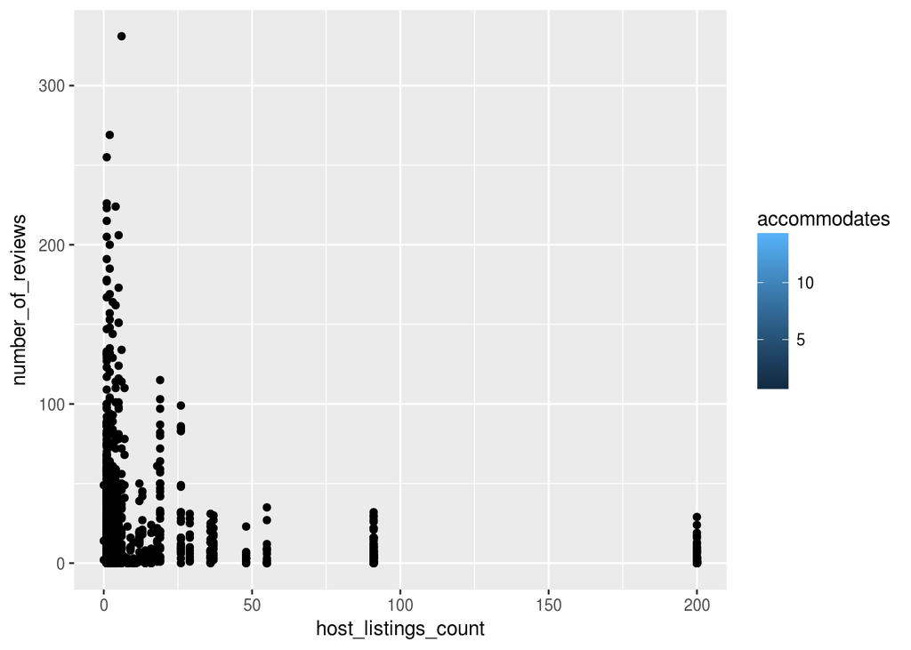

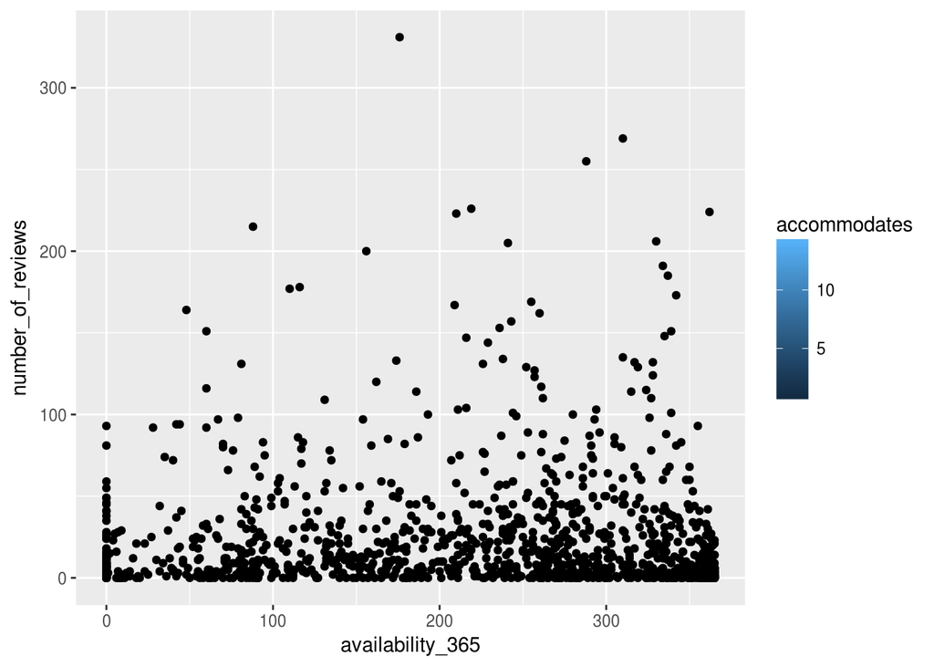

### Precio por noche

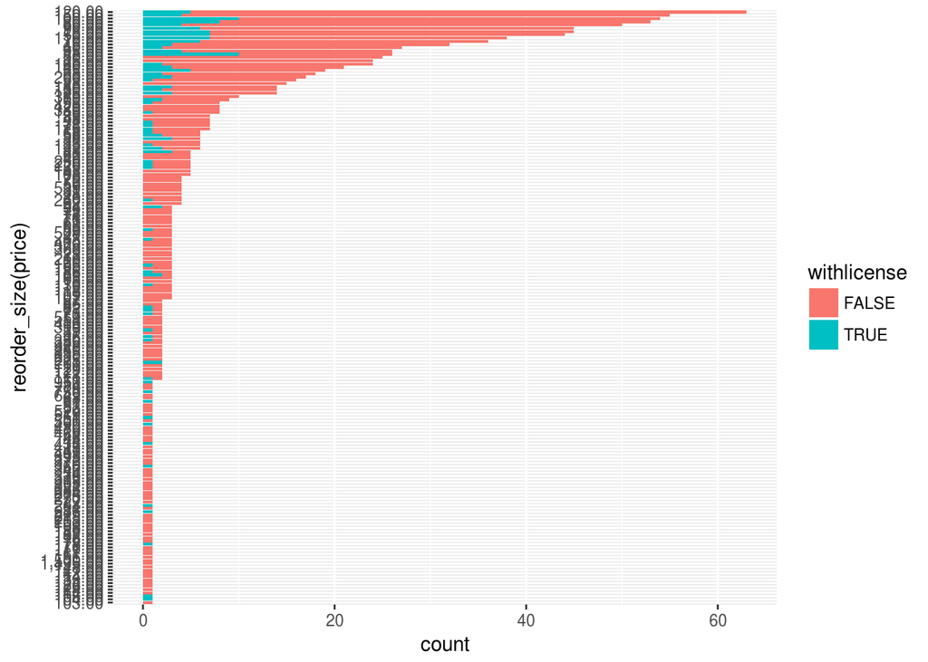

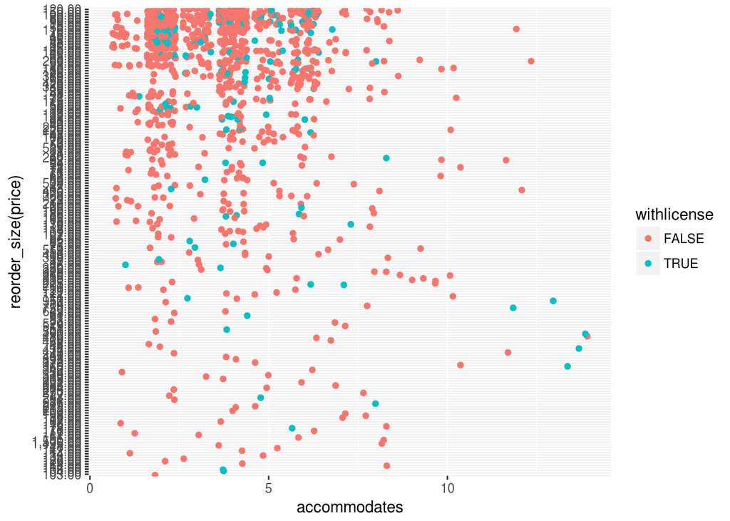

## Otros

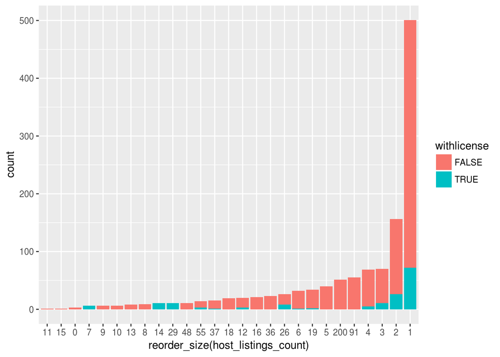

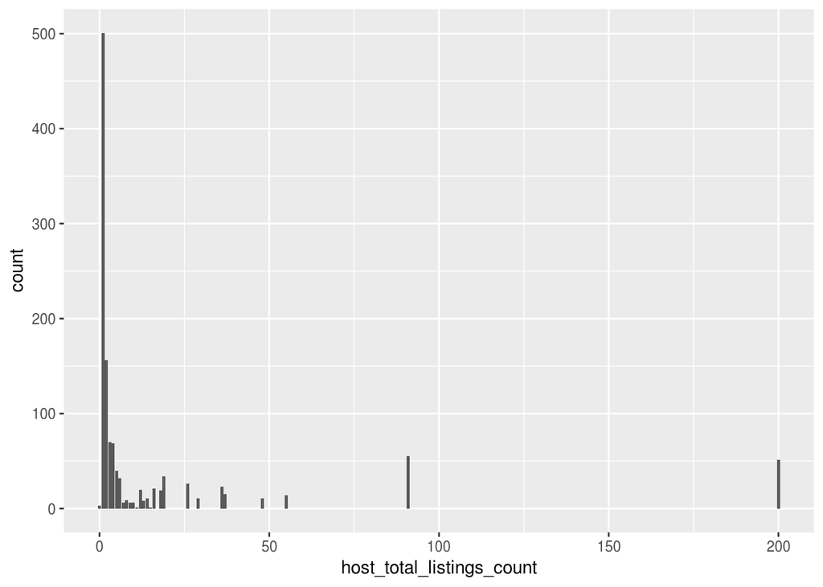

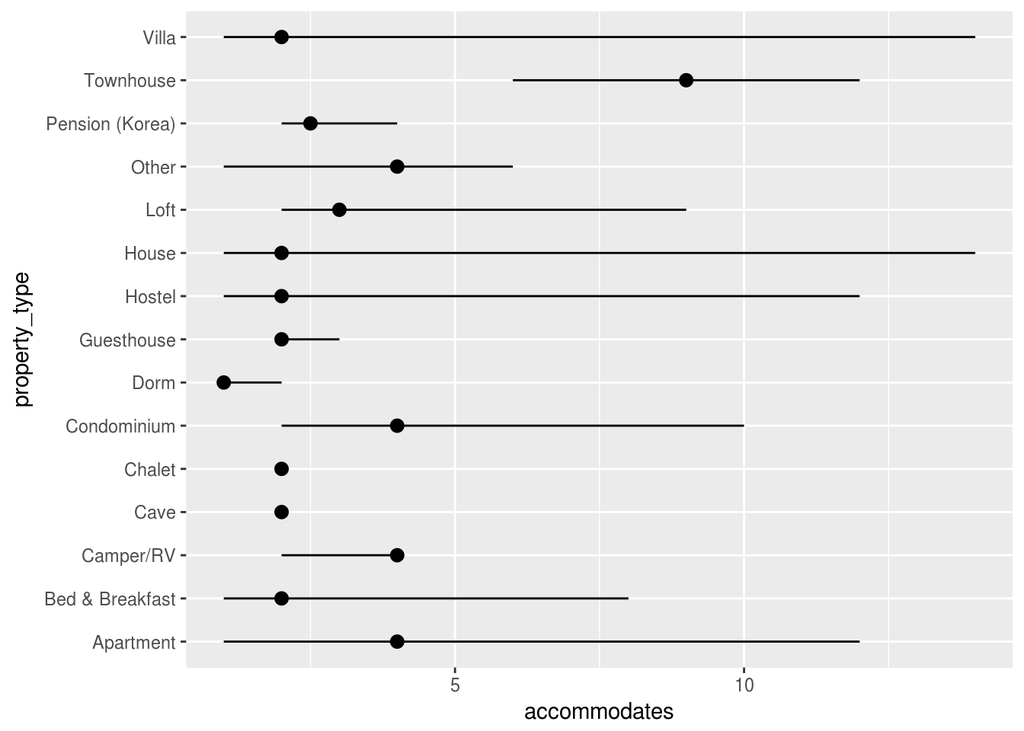

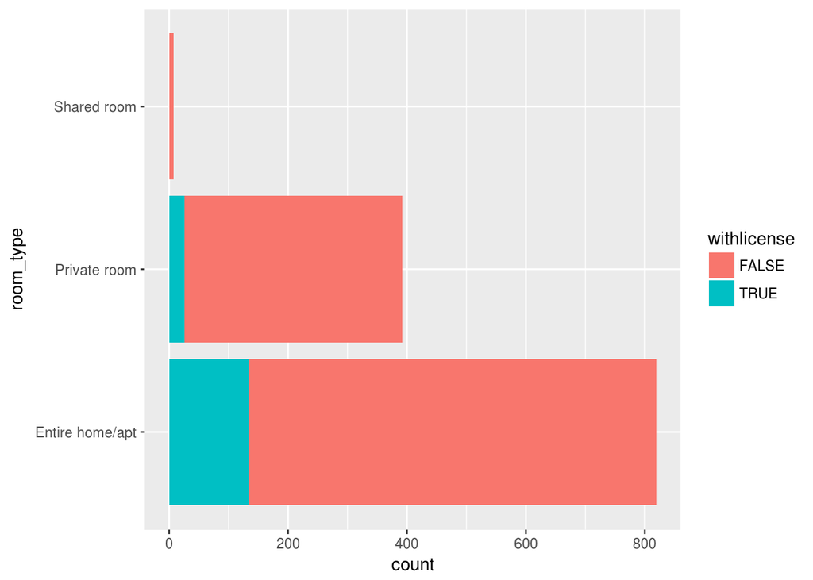

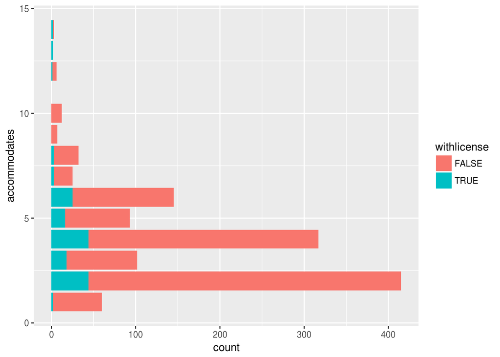

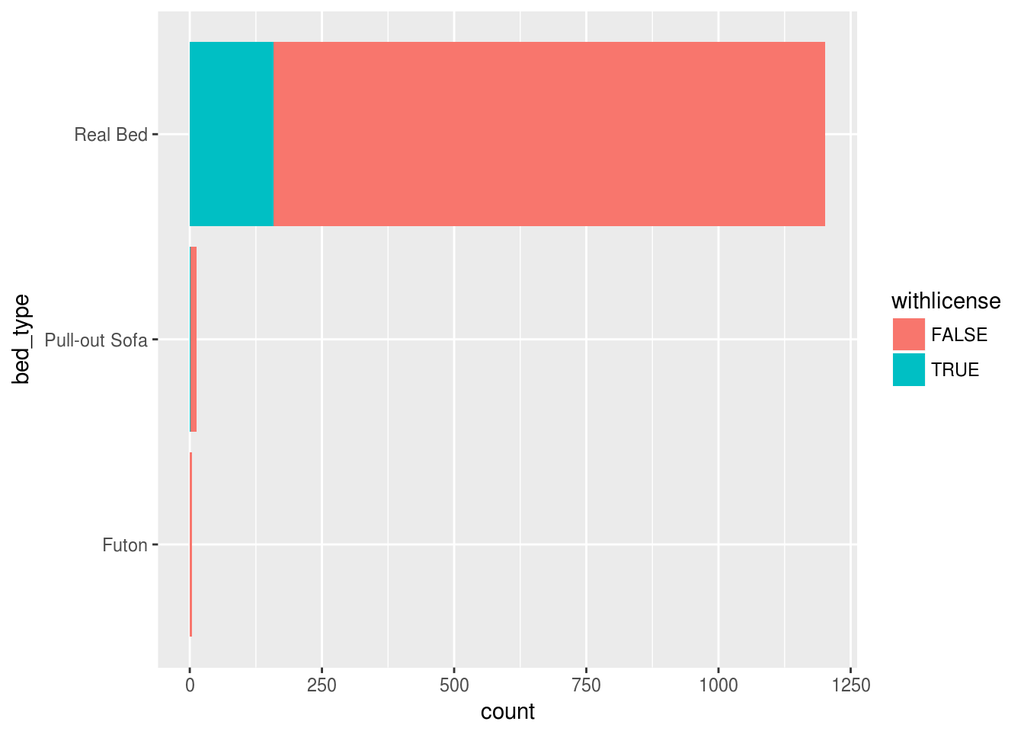

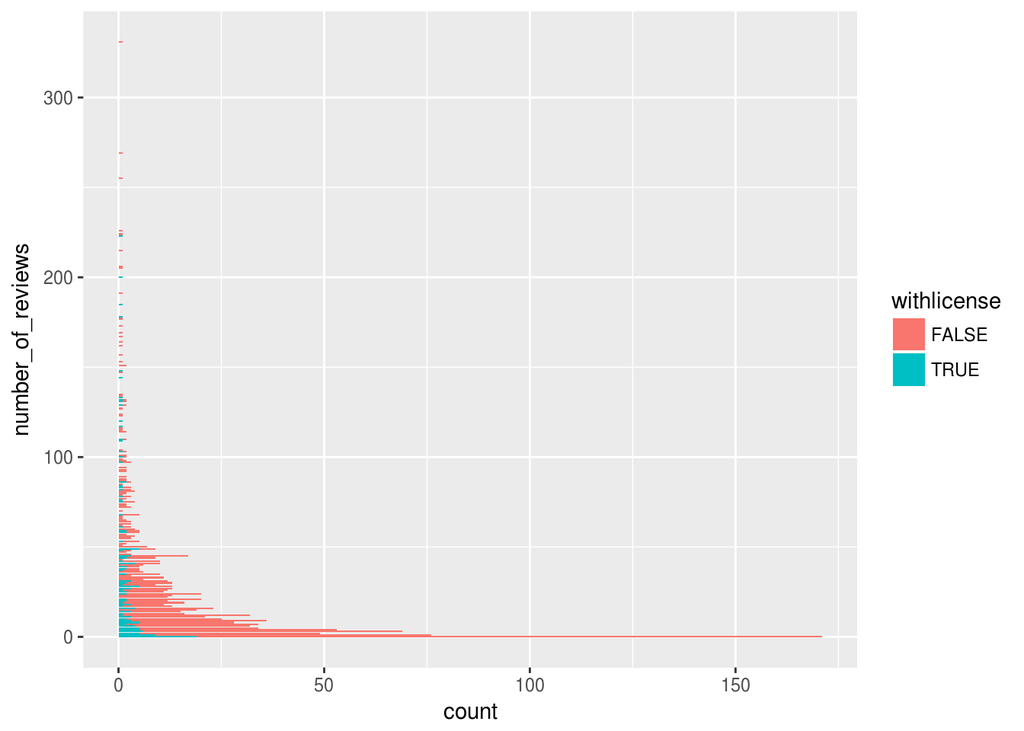

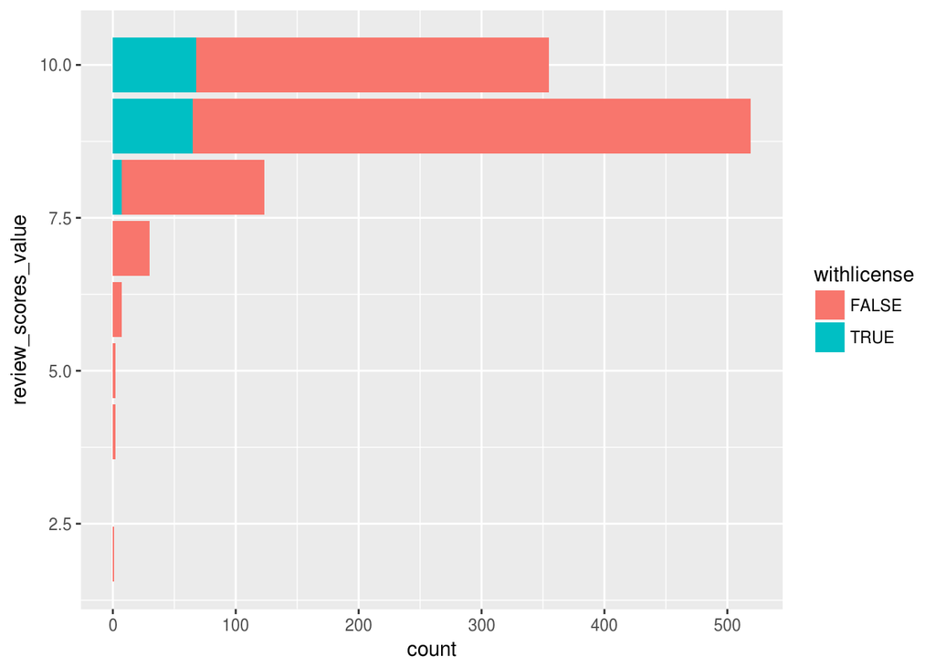

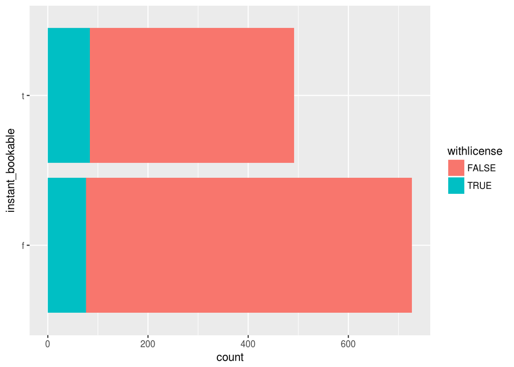

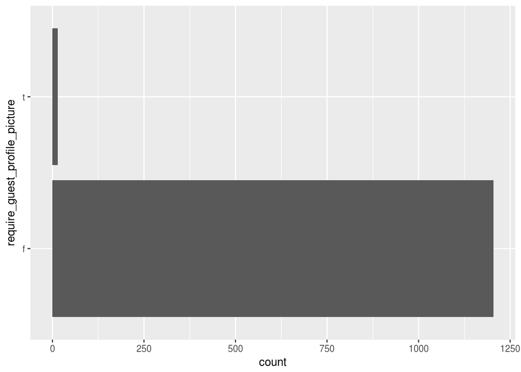

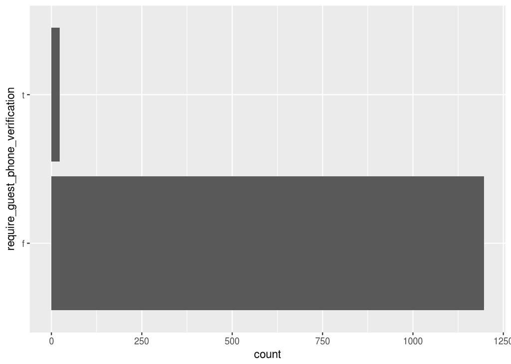

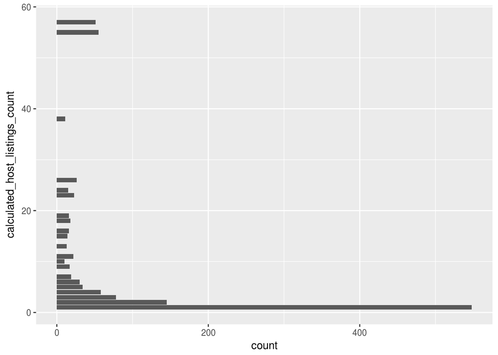

[6 more figures not shown]

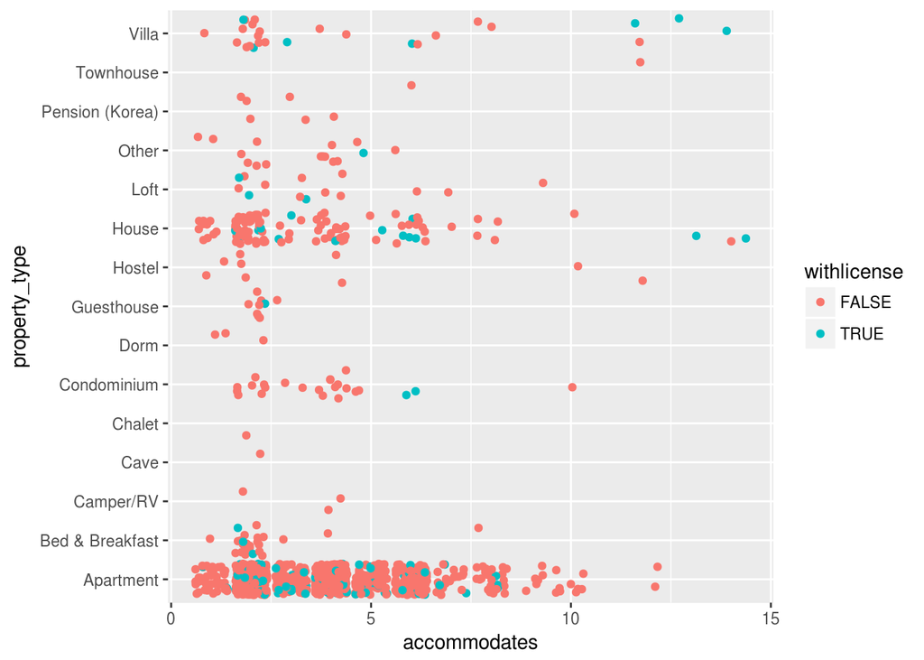

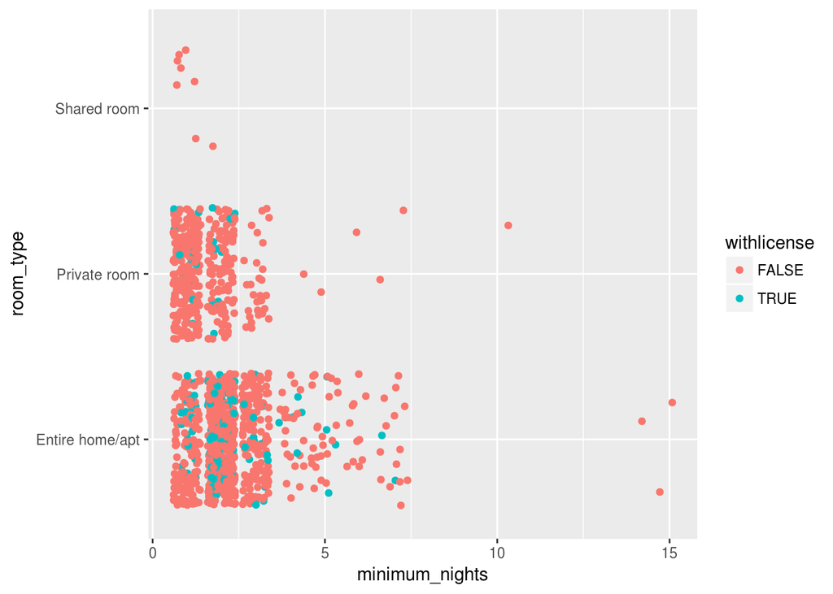

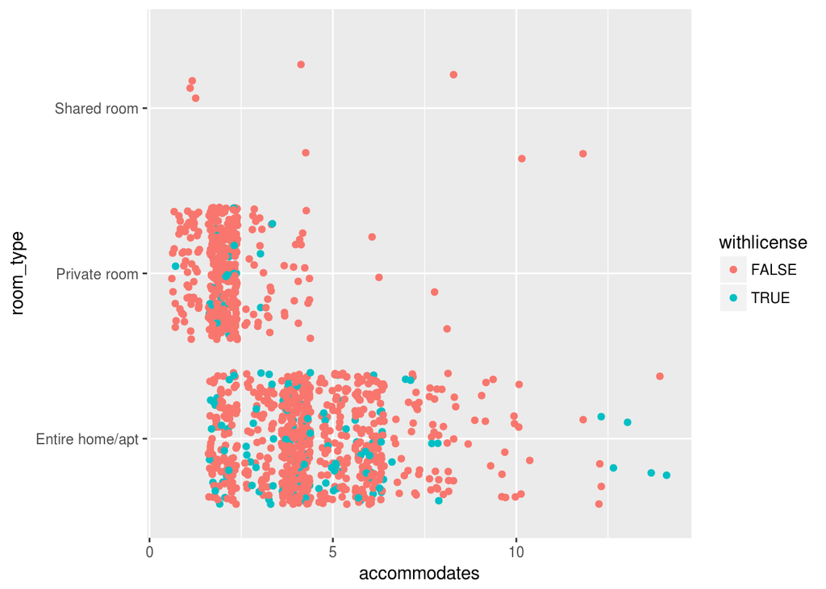